# A large family is not good for Survival on the Titanic

A policy of “women and child first” on the Titanic is clearly demonstrated by the data but appears that having a large family was also not good for chances of survival.

If a person had 5 family members or more (including themselves) then more likely that person didn’t survive especially in the third class which had entire families onboard.

# Load data and setup factors

```r
loaddata <- function(file) {
 data <- read.csv(file, header = TRUE, stringsAsFactors=F)
 # compute family size on dataset (including self)
 data$FamilySize <- data$SibSp + data$Parch + 1

 data
}

data <- loaddata("train.csv")
# load real test data
titanic_test <- loaddata("test.csv")

# change survived from integer to boolean

data$Survived <- as.logical(data$Survived)
levels(data$Survived) <- c("Not survived", "Survived")

# make explicit factor levels for specific variables: 3=Pclass, 5=Sex, 12=Embarked
for(i in c(3,5,12)) {
  data[,i] <- as.factor(data[,i])
}
```

# Age, Sex, and Pclass best predictors for survival

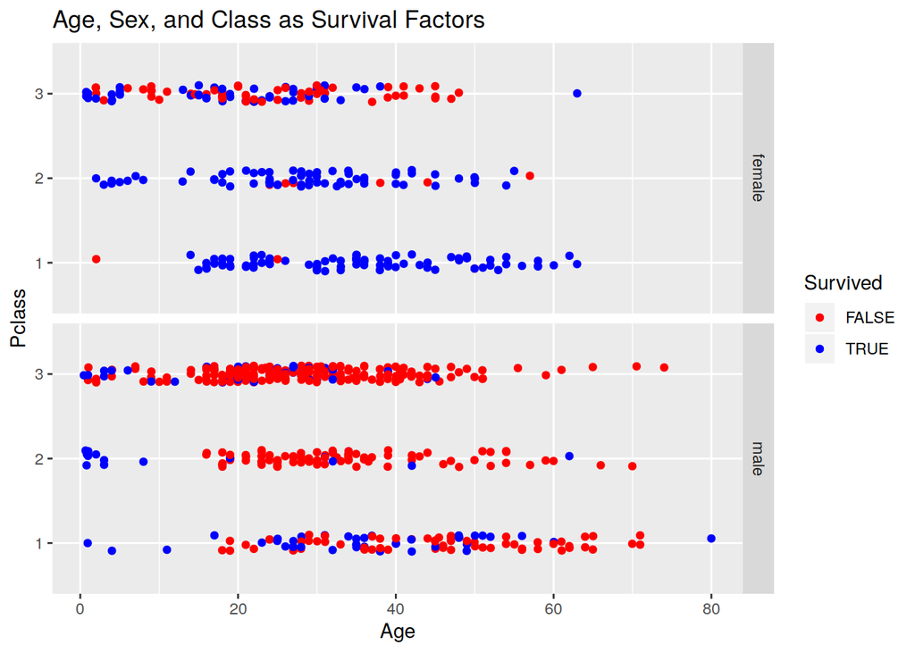

```r
library(ggplot2)
ggplot(data, aes(x=Age, y=Pclass, color=Survived)) +
  geom_jitter(position = position_jitter(height = .1)) +
  scale_color_manual(values=c("red", "blue")) + facet_grid(Sex ~ .) +
  ggtitle("Age, Sex, and Class as Survival Factors") + ylab("Pclass")
```

## Create adjusted family size variable for people sharing cabins but not registered as family members

```r
# e.g., if two people assigned to cabin A13 and familysize == 1 then bump up familysize to 2
# combine set of cabins from both test and training data
cabins <- data$Cabin # 1309 rows
n_occur <- data.frame(table(Var1=cabins))   # 187 rows
# remove missing cabin and/or juse the cabin letter code (e.g. D)
n_occur <- subset(n_occur, nchar(as.character(Var1)) > 1) # 183 rows

sharedCabins <- n_occur$Var1[n_occur$Freq > 1]
data$FamilySizeAdj <- data$FamilySize
print(table(data$FamilySize))
```

```
##
##   1   2   3   4   5   6   7   8  11
## 537 161 102  29  15  22  12   6   7
```

```r
sharedInd <- data$FamilySizeAdj == 1 & data$Cabin %in% sharedCabins
data$FamilySizeAdj[sharedInd] <- 2
rowCount <- sum(sharedInd)
print(c("adjusted rows", rowCount)) # 27 rows
```

```
## [1] "adjusted rows" "27"
```

```r
print(table(data$FamilySizeAdj))
```

```
##
##   1   2   3   4   5   6   7   8  11
## 510 188 102  29  15  22  12   6   7
```

# Break up training set into subset training and test set

```r
library(caret)
set.seed(820)
inTrainingSet <- createDataPartition(data$Survived, p = 0.5, list=FALSE)
train <- data[inTrainingSet,]
test <- data[-inTrainingSet,]
```

# Does adding more variables improve predictions???

```r
modelaccuracy <- function(test, rpred) {
  result_1 <- test$Survived == rpred
  sum(result_1) / length(rpred)
}

checkaccuracy <- function(accuracy) {
    if (accuracy > bestaccuracy) {
     bestaccuracy <- accuracy
     assign("bestaccuracy", accuracy, envir = .GlobalEnv)
     label <- 'better'
    } else if (accuracy < bestaccuracy) {
     label <- 'worse'
    } else {
     label <- 'no change'
    }
    label
}

library(rpart)
# starting with Age and Sex as indicators
fol <- formula(Survived ~ Age + Sex)                        # 0.845
rmodel <- rpart(fol, method="class", data=train)
rpred <- predict(rmodel, newdata=test, type="class")
accuracy <- modelaccuracy(test, rpred)
bestaccuracy <- accuracy # init base accuracy
print(c("accuracy1", accuracy))                             # baseline
```

```
## [1] "accuracy1"         "0.786516853932584"
```

# Add Pclass variable

```r
fol <- formula(Survived ~ Age + Sex + Pclass)               # 0.838
rmodel <- rpart(fol, method="class", data=train)
rpred <- predict(rmodel, newdata=test, type="class")
accuracy <- modelaccuracy(test, rpred)
accuracyLabel <- checkaccuracy(accuracy)
# almost as good but little worse
print(c("accuracy2", accuracy, accuracyLabel))              # worse
```

```
## [1] "accuracy2"         "0.793258426966292" "better"
```

# Substitute Pclass with fare variable

```r
fol <- formula(Survived ~ Age + Sex + Fare)                 # 0.807
rmodel <- rpart(fol, method="class", data=train)
rpred <- predict(rmodel, newdata=test, type="class")
accuracy <- modelaccuracy(test, rpred)
accuracyLabel <- checkaccuracy(accuracy)
print(c("accuracy3", accuracy, accuracyLabel))              # worse
```

```
## [1] "accuracy3"         "0.786516853932584" "worse"
```

# Add back Pclass variable

```r
fol <- formula(Survived ~ Age + Sex + Pclass + Fare)        # 0.820
rmodel <- rpart(fol, method="class", data=train)
rpred <- predict(rmodel, newdata=test, type="class")
#print(rmodel)
accuracy <- modelaccuracy(test, rpred)
accuracyLabel <- checkaccuracy(accuracy)
print(c("accuracy4", accuracy, accuracyLabel))              # worse
```

```
## [1] "accuracy4"         "0.808988764044944" "better"
```

# Add SibSp + Parch variables

```r
fol <- formula(Survived ~ Age + Sex + Pclass + Fare + SibSp + Parch) # 0.838
rmodel <- rpart(fol, method="class", data=train)
rpred <- predict(rmodel, newdata=test, type="class")
print(rmodel)
```

```
## n= 446
##
## node), split, n, loss, yval, (yprob)
##       * denotes terminal node
##
##   1) root 446 171 FALSE (0.61659193 0.38340807)
##     2) Sex=male 284  51 FALSE (0.82042254 0.17957746)
##       4) Age>=3.5 274  43 FALSE (0.84306569 0.15693431) *
##       5) Age< 3.5 10   2 TRUE (0.20000000 0.80000000) *
##     3) Sex=female 162  42 TRUE (0.25925926 0.74074074)
##       6) Pclass=3 73  35 FALSE (0.52054795 0.47945205)
##        12) Fare>=22.90415 12   1 FALSE (0.91666667 0.08333333) *
##        13) Fare< 22.90415 61  27 TRUE (0.44262295 0.55737705)
##          26) Age>=16.5 47  23 FALSE (0.51063830 0.48936170)
##            52) Fare>=7.8875 26   9 FALSE (0.65384615 0.34615385)
##             104) Fare< 15 18   3 FALSE (0.83333333 0.16666667) *
##             105) Fare>=15 8   2 TRUE (0.25000000 0.75000000) *
##            53) Fare< 7.8875 21   7 TRUE (0.33333333 0.66666667) *
##          27) Age< 16.5 14   3 TRUE (0.21428571 0.78571429) *
##       7) Pclass=1,2 89   4 TRUE (0.04494382 0.95505618) *
```

```r
accuracy <- modelaccuracy(test, rpred)
accuracyLabel <- checkaccuracy(accuracy)
print(c("accuracy5", accuracy, accuracyLabel))              # worse
```

```
## [1] "accuracy5"        "0.81123595505618" "better"
```

# Test if deck letter helps predict survivability

```r
# strip off cabin numbers
# Extract the deck number
# first letter : Deck (e.g. A31 -> A)

# make sure Deck in both sets has same levels
# if Test set has T but not Train set different levels causes error in model
train$Deck <- substr(train$Cabin,1,1)
train$Deck[train$Deck==''] = NA
test$Deck <- substr(test$Cabin,1,1)
test$Deck[test$Deck==''] = NA

train$Deck <- as.factor(train$Deck)
test$Deck <- as.factor(test$Deck)

# make Deck have same levels
c <- union(levels(train$Deck), levels(test$Deck))
levels(test$Deck) <- c
levels(train$Deck) <- c

# test if deck letter improves the prediction

fol <- formula(Survived ~ Age + Sex + Pclass + SibSp + Parch + Fare + Deck) # 0.807
rmodel <- rpart(fol, method="class", data=train)
rpred <- predict(rmodel, newdata=test, type="class")
#print(rmodel)
accuracy <- modelaccuracy(test, rpred)
accuracyLabel <- checkaccuracy(accuracy)
print(c("accuracy6", accuracy, accuracyLabel))                          # 0.807 worse
```

```
## [1] "accuracy6"        "0.81123595505618" "no change"
```